# Assignment 2

Anjali Pal

29 April 2021

**This assignment included data cleaning, use of dplyr and working with dates.**

### Question 1

The final score of the World Cup finals of football is France 4 and Croatia 2. Please use a control structure to print the results as Team —- Wins —–.

```r
country <- c('France','Croatia')
wins <- c(4,2)
for (i in 1:2){
  print(sprintf("Team %s wins %d",country[i],wins[i]))
}
```

```
## [1] "Team France wins 4"
## [1] "Team Croatia wins 2"
```

### Question 2

The mtcars data set has several factor variables. However, R is reading them as numeric. Please convert them into factors using a for loop. Please use column 8 to 11 for the loop.

```r
head(mtcars)
```

```
##                    mpg cyl disp  hp drat    wt  qsec vs am gear carb
## Mazda RX4         21.0   6  160 110 3.90 2.620 16.46  0  1    4    4
## Mazda RX4 Wag     21.0   6  160 110 3.90 2.875 17.02  0  1    4    4
## Datsun 710        22.8   4  108  93 3.85 2.320 18.61  1  1    4    1
## Hornet 4 Drive    21.4   6  258 110 3.08 3.215 19.44  1  0    3    1
## Hornet Sportabout 18.7   8  360 175 3.15 3.440 17.02  0  0    3    2
## Valiant           18.1   6  225 105 2.76 3.460 20.22  1  0    3    1
```

```r
cars<-mtcars

for (i in 8:11){
  cars[,i]<- as.factor(cars[,i])
}
str(cars[8:11])
```

```
## 'data.frame':    32 obs. of  4 variables:
##  $ vs  : Factor w/ 2 levels "0","1": 1 1 2 2 1 2 1 2 2 2 ...
##  $ am  : Factor w/ 2 levels "0","1": 2 2 2 1 1 1 1 1 1 1 ...
##  $ gear: Factor w/ 3 levels "3","4","5": 2 2 2 1 1 1 1 2 2 2 ...
##  $ carb: Factor w/ 6 levels "1","2","3","4",..: 4 4 1 1 2 1 4 2 2 4 ...
```

A subset of real data is provided for questions 3-6.

### Question 3

Write a function to get the percentage of NAs in each column.

```r
data <- read.csv("C:/Users/Lenovo PC/Downloads/cat.csv")
library(dplyr)
Percent_Col_NA <- function(x){
  num<-nrow(x)
  percent<-(colSums(is.na(x))/num)*100
  return(percent)
}
data<-data %>% na_if("#N/A")
Percent_Col_NA(data)
```

```
##                           Year                   Veh.Mfr.Code
##                            0.0                            0.0
##      Represented.Test.Veh.Make     Represented.Test.Veh.Model
##                            0.0                            0.0
##        Test.Veh.Displacement.L                   Vehicle.Type
##                            0.0                            0.0
##               Rated.Horsepower     No.of.Cylinders.and.Rotors
##                            0.0                           13.9
##                    Engine.Code       Tested.Transmission.Type
##                            0.0                            0.0
##                    No.of.Gears           Transmission.Lockup.
##                            0.0                            0.0
##       Drive.System.Description    Transmission.Overdrive.Desc
##                            0.0                            0.0
##     Equivalent.Test.Weight.lbs                     Axle.Ratio
##                            0.0                            0.0
##                      N.V.Ratio Shift.Indicator.Light.Use.Desc
##                            0.0                            0.0
##     Test.Procedure.Description              Test.Fuel.Type.Cd
##                            0.0                            0.0
##     Test.Fuel.Type.Description                  Test.Category
##                            0.0                            0.0
##                            THC                             CO
##                            8.2                            7.8
##                            CO2                            NOx
##                            7.9                            8.8
##                            CH4                            N2O
##                           46.2                           73.2
##                     RND_ADJ_FE                       FE.Bag.1
##                            0.3                           71.8
##                       FE.Bag.2                       FE.Bag.3
##                           72.3                           76.2
##                  Target.Coef.A             Target.Coef.B.mph.
##                            0.0                            0.0
##            Target.Coef.C.mph.2                    Set.Coef.A.
##                            0.0                            0.0
##                Set.Coef.B.mph.               Set.Coef.C.mph.2
##                            0.0                            0.0
##       Aftertreatment.Device.Cd     Aftertreatment.Device.Desc
##                           17.5                           17.5
##       Police.Emergency.Vehicle                             ID
##                            0.0                            0.0
```

### Question 4

Write a function to get the percentage of NAs in each row.

```r
# data <- read.csv("C:/Users/Lenovo PC/Downloads/cat.csv")
# library(dplyr)
Percent_Row_NA <- function(x){
  num<-ncol(x)
  percent<-(rowSums(is.na(x))/num)*100
  return(percent)
}
# data<-data %>% na_if("#N/A")
Percent_Row_NA(data)
```

```
##    [1]  2.380952  9.523810 21.428571 21.428571 21.428571  7.142857 19.047619
##    [8] 11.904762 19.047619  4.761905 11.904762 19.047619  7.142857  2.380952
##   [15]  9.523810 11.904762  0.000000 28.571429  9.523810  4.761905  7.142857
##   [22]  7.142857 11.904762  2.380952  2.380952 19.047619  4.761905 14.285714
##   [29]  2.380952 14.285714 19.047619 11.904762 11.904762  9.523810 19.047619
##   [36]  2.380952 11.904762  7.142857  2.380952 11.904762 28.571429 14.285714
##   [43] 11.904762  7.142857  9.523810 14.285714  9.523810  2.380952  2.380952
##   [50]  7.142857  7.142857 11.904762 21.428571  7.142857  9.523810 19.047619
##   [57]  2.380952  4.761905 14.285714  7.142857  4.761905  2.380952  7.142857
##   [64]  7.142857 21.428571  7.142857  7.142857 21.428571  7.142857  7.142857
##   [71] 11.904762  7.142857 11.904762 11.904762 16.666667 11.904762 11.904762
##   [78] 11.904762 11.904762 11.904762  4.761905  7.142857 11.904762  2.380952
##   [85]  0.000000 11.904762  7.142857 11.904762  2.380952  2.380952 11.904762
##   [92]  2.380952 11.904762  7.142857 11.904762  7.142857 11.904762  4.761905
##   [99]  9.523810  0.000000 19.047619  2.380952  4.761905  7.142857 11.904762
```

[output cut: 128 more lines]

### Question 5

Write a function to get a summary of numeric columns (use the summary function) such as THC, CO, CO2, and so on in the data set. With the same function, try to generate box plot using base R.

```
## [1] "Year"
##    Min. 1st Qu.  Median    Mean 3rd Qu.    Max.
##    2010    2010    2011    2011    2012    2012
```

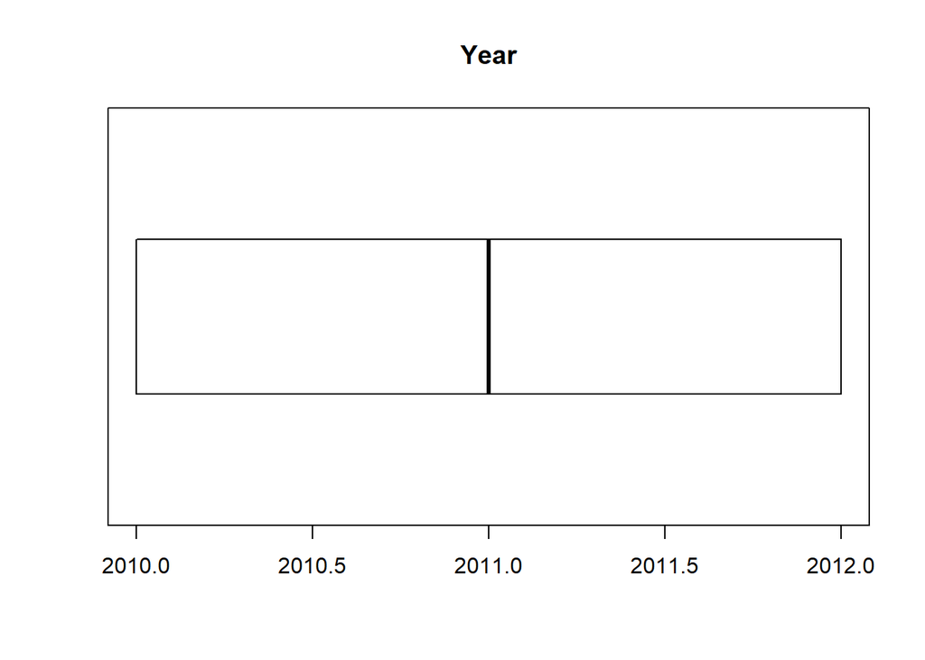

```
## $stats
##      [,1]
## [1,] 2010
## [2,] 2010
## [3,] 2011
## [4,] 2012
## [5,] 2012
## attr(,"class")
##
## "integer"
##
## $n
## [1] 1000
##
## $conf
##        [,1]
## [1,] 2010.9
## [2,] 2011.1
##
## $out
## numeric(0)
##
## $group
## numeric(0)
##
## $names
## [1] ""
##
## [1] "Test.Veh.Displacement.L"
##    Min. 1st Qu.  Median    Mean 3rd Qu.    Max.
##   0.001   2.400   3.499   3.532   4.600   6.800
```

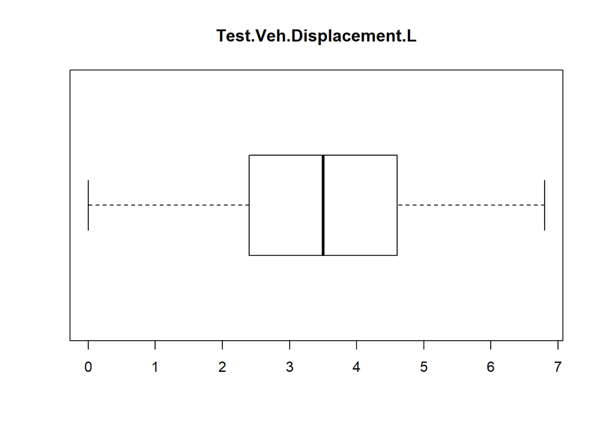

```
## $stats
##       [,1]
## [1,] 0.001
## [2,] 2.400
## [3,] 3.499
## [4,] 4.600
## [5,] 6.800
##
## $n
## [1] 1000
##
## $conf
##          [,1]
## [1,] 3.389079
## [2,] 3.608921
##
## $out
## numeric(0)
##
## $group
## numeric(0)
##
## $names
## [1] ""
##
## [1] "Rated.Horsepower"
##    Min. 1st Qu.  Median    Mean 3rd Qu.    Max.
##    45.0   179.2   261.0   273.0   320.0   656.0
```

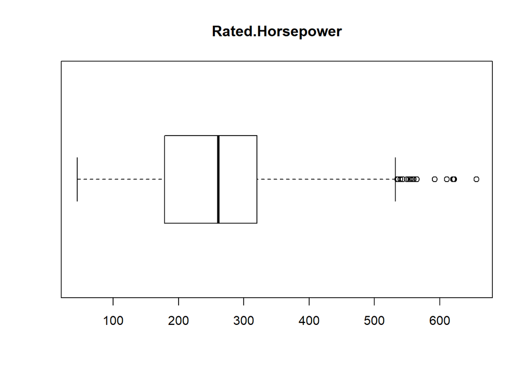

```
## $stats
##       [,1]
## [1,]  45.0
## [2,] 178.5
## [3,] 261.0
## [4,] 320.0
## [5,] 532.0
## attr(,"class")
##
## "integer"
##
## $n
## [1] 1000
##
## $conf
##          [,1]
## [1,] 253.9301
## [2,] 268.0699
##
## $out
##  [1] 560 550 656 621 535 621 560 553 621 555 621 555 540 621 611 558 620 592 620
## [20] 543 558 535 553 550 556 543 621 565 621 555 622 621 536 621
##
## $group
##  [1] 1 1 1 1 1 1 1 1 1 1 1 1 1 1 1 1 1 1 1 1 1 1 1 1 1 1 1 1 1 1 1 1 1 1
##
## $names
## [1] ""
##
## [1] "No.of.Gears"
##    Min. 1st Qu.  Median    Mean 3rd Qu.    Max.
##   1.000   5.000   6.000   5.484   6.000   8.000
```

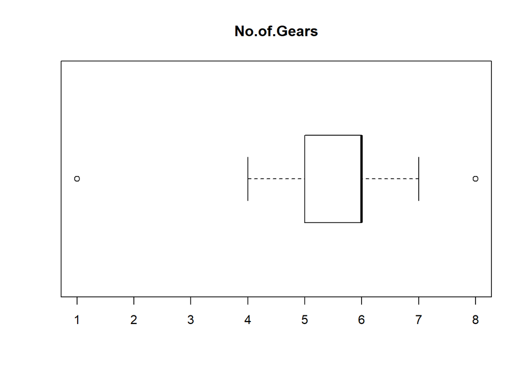

```
## $stats
##      [,1]
## [1,]    4
## [2,]    5
## [3,]    6
## [4,]    6
## [5,]    7
## attr(,"class")
##
## "integer"
##
## $n
## [1] 1000
##
## $conf
##          [,1]
## [1,] 5.950036
## [2,] 6.049964
##
## $out
##   [1] 8 8 1 1 1 1 1 1 1 8 1 8 8 1 1 1 8 8 8 1 8 1 1 1 1 8 8 8 8 1 1 8 1 1 1 8 1
##  [38] 8 8 1 1 1 8 8 1 1 1 1 1 1 1 1 8 1 8 1 8 1 8 1 8 8 1 1 8 8 1 8 1 1 1 1 8 1
##  [75] 8 1 1 1 8 8 8 1 1 1 1 1 8 1 1 1 1 8 8 1 1 8 8 1 8 8 1 1 1 1 8 8 1 8 1 1 8
## [112] 1 1 8 1 1 1 1 1 8
##
## $group
##   [1] 1 1 1 1 1 1 1 1 1 1 1 1 1 1 1 1 1 1 1 1 1 1 1 1 1 1 1 1 1 1 1 1 1 1 1 1 1
##  [38] 1 1 1 1 1 1 1 1 1 1 1 1 1 1 1 1 1 1 1 1 1 1 1 1 1 1 1 1 1 1 1 1 1 1 1 1 1
##  [75] 1 1 1 1 1 1 1 1 1 1 1 1 1 1 1 1 1 1 1 1 1 1 1 1 1 1 1 1 1 1 1 1 1 1 1 1 1
## [112] 1 1 1 1 1 1 1 1 1
##
## $names
## [1] ""
##
## [1] "Equivalent.Test.Weight.lbs"
##    Min. 1st Qu.  Median    Mean 3rd Qu.    Max.
##    2375    3625    4250    4351    5000    8500
```

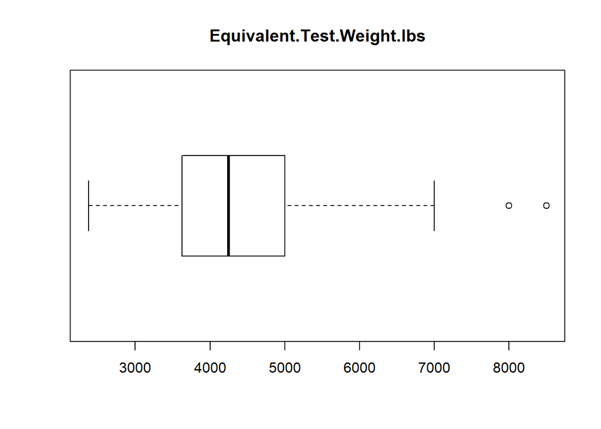

```
## $stats
##      [,1]
## [1,] 2375
## [2,] 3625
## [3,] 4250
## [4,] 5000
## [5,] 7000
## attr(,"class")
##
## "integer"
##
## $n
## [1] 1000
##
## $conf
##        [,1]
## [1,] 4181.3
## [2,] 4318.7
##
## $out
## [1] 8500 8000
##
## $group
## [1] 1 1
##
## $names
## [1] ""
##
## [1] "Axle.Ratio"
##    Min. 1st Qu.  Median    Mean 3rd Qu.    Max.
##   2.060   3.147   3.500   3.585   3.910   9.730
```

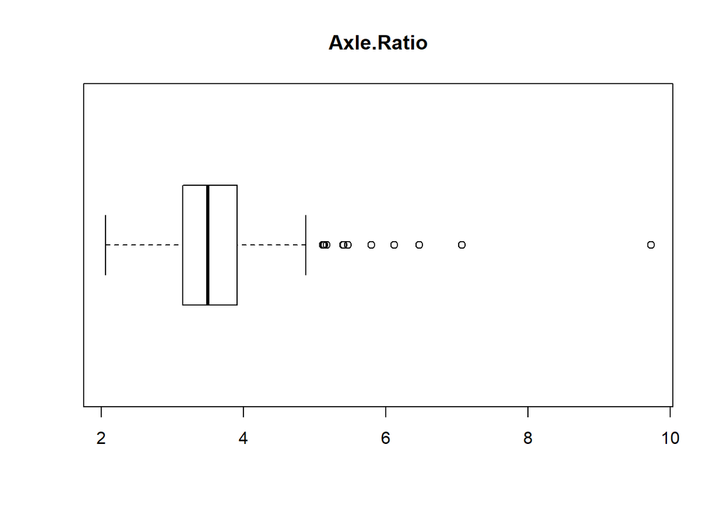

```
## $stats
##       [,1]
## [1,] 2.060
## [2,] 3.145
## [3,] 3.500
## [4,] 3.910
## [5,] 4.880
##
## $n
## [1] 1000
##
## $conf
##          [,1]
## [1,] 3.461778
## [2,] 3.538222
##
## $out
##  [1] 7.07 5.80 5.12 5.12 5.80 5.13 6.47 5.40 6.12 5.41 5.47 5.47 5.13 5.13 5.80
## [16] 9.73 5.14 6.47 6.12 6.47 5.80 5.14 5.17 6.47 5.47 6.12 5.80 6.47 6.47 6.12
## [31] 5.41 6.12 6.12 6.12
##
## $group
##  [1] 1 1 1 1 1 1 1 1 1 1 1 1 1 1 1 1 1 1 1 1 1 1 1 1 1 1 1 1 1 1 1 1 1 1
##
## $names
## [1] ""
##
## [1] "N.V.Ratio"
##    Min. 1st Qu.  Median    Mean 3rd Qu.    Max.
##     9.7    27.8    31.0    32.1    35.6   106.2
```

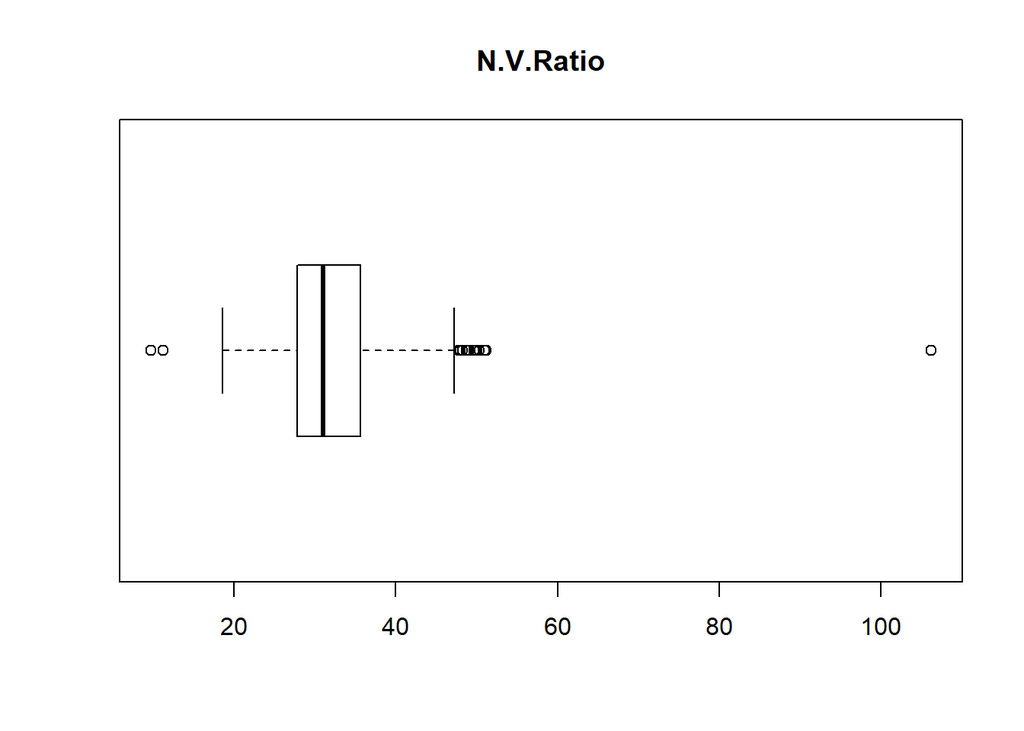

```
## $stats
##      [,1]
## [1,] 18.6
## [2,] 27.8
## [3,] 31.0
## [4,] 35.6
## [5,] 47.2
##
## $n
## [1] 1000
##
## $conf
##          [,1]
## [1,] 30.61028
## [2,] 31.38972
##
## $out
##  [1] 106.2  48.3  49.7  48.0  49.1  51.2  51.2  47.9  48.9  48.7  48.7  48.9
## [13]   9.7  51.0  49.9  11.2  48.9  50.3  48.3  47.8
##
## $group
##  [1] 1 1 1 1 1 1 1 1 1 1 1 1 1 1 1 1 1 1 1 1
##
## $names
## [1] ""
##
## [1] "Test.Fuel.Type.Cd"
##    Min. 1st Qu.  Median    Mean 3rd Qu.    Max.
##    6.00   61.00   61.00   54.69   61.00   62.00
```

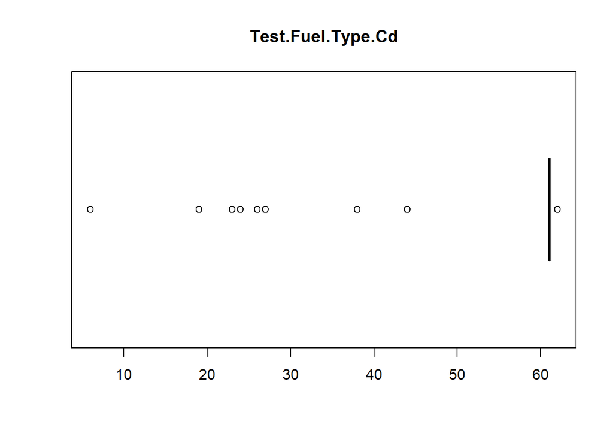

```
## $stats
##      [,1]
## [1,]   61
## [2,]   61
## [3,]   61
## [4,]   61
## [5,]   61
## attr(,"class")
##
## "integer"
##
## $n
## [1] 1000
##
## $conf
##      [,1]
## [1,]   61
## [2,]   61
##
## $out
##   [1] 19 38 19 23 23 23 38 23 38 38 62  6 27 26 27 38 26 19 27 23 19 38 23 23 38
##  [26] 23 38 23 23 38 23 19 27 27 27 23 26 19 27 38 23 38 38 38 19 38 38 38 19 44
##  [51] 19 19 19 24 19 38 38 23 19 19 38 19 19 38 38 38 38 38 38 19 38 38 27 19 27
##  [76] 38 38 23 38 23 23 38 19 23 26 27 23 27 38 19 23 19 38 38 38 38 38 19 19 27
## [101] 19 19 27 38 38 44 23 24  6 38 19 23 26 38 23 38 27 38 38 38 19 19 19 38 19
## [126] 23 27 23 19 38 62 24 38 38 23 38 19 27 38 38 23 19 19 38 38 23 38 27 38 38
## [151] 26 38 38 26 23 23 23 38 23 27 19 23 23 23 19 23 38 38 27 26 38 23 19 23 23
## [176] 38 38 38 38 38 23 19 23 23 19 38 27 38 19 38 38 23 23 23  6
##
## $group
##   [1] 1 1 1 1 1 1 1 1 1 1 1 1 1 1 1 1 1 1 1 1 1 1 1 1 1 1 1 1 1 1 1 1 1 1 1 1 1
##  [38] 1 1 1 1 1 1 1 1 1 1 1 1 1 1 1 1 1 1 1 1 1 1 1 1 1 1 1 1 1 1 1 1 1 1 1 1 1
##  [75] 1 1 1 1 1 1 1 1 1 1 1 1 1 1 1 1 1 1 1 1 1 1 1 1 1 1 1 1 1 1 1 1 1 1 1 1 1
## [112] 1 1 1 1 1 1 1 1 1 1 1 1 1 1 1 1 1 1 1 1 1 1 1 1 1 1 1 1 1 1 1 1 1 1 1 1 1
## [149] 1 1 1 1 1 1 1 1 1 1 1 1 1 1 1 1 1 1 1 1 1 1 1 1 1 1 1 1 1 1 1 1 1 1 1 1 1
## [186] 1 1 1 1 1 1 1 1 1 1
##
## $names
## [1] ""
##
## [1] "THC"
##    Min. 1st Qu.  Median    Mean 3rd Qu.    Max.    NA's
##     2.0   148.2   331.5   338.3   516.8   720.0      82
```

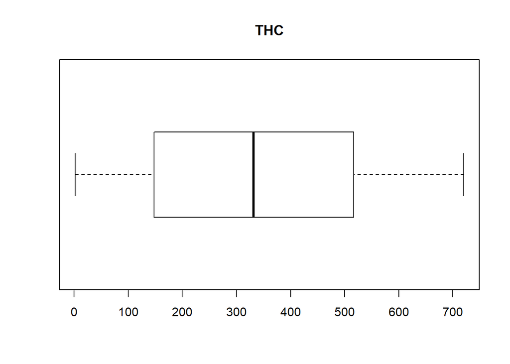

```
## $stats
##       [,1]
## [1,]   2.0
## [2,] 148.0
## [3,] 331.5
## [4,] 517.0
## [5,] 720.0
##
## $n
## [1] 918
##
## $conf
##          [,1]
## [1,] 312.2575
## [2,] 350.7425
##
## $out
## numeric(0)
##
## $group
## numeric(0)
##
## $names
## [1] ""
##
## [1] "CO"
##    Min. 1st Qu.  Median    Mean 3rd Qu.    Max.    NA's
##     2.0   186.2   376.5   385.1   582.8   796.0      78
```

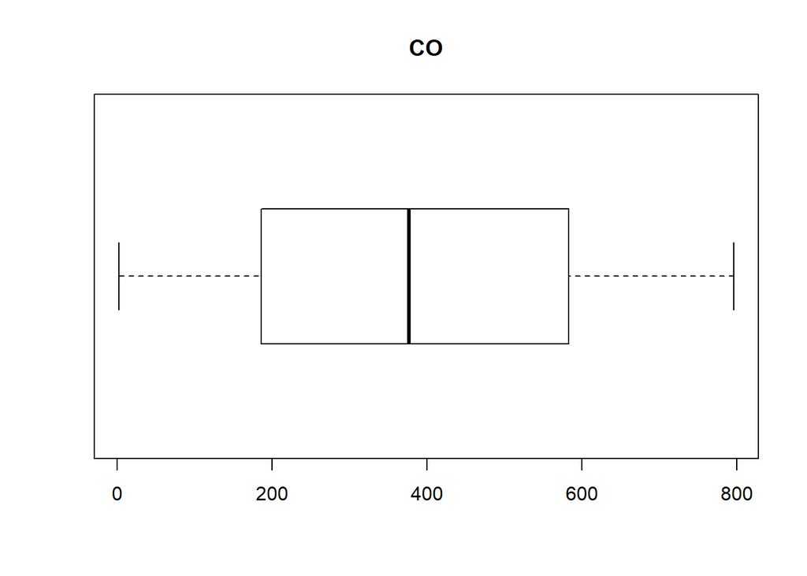

```
## $stats
##       [,1]
## [1,]   2.0
## [2,] 186.0
## [3,] 376.5
## [4,] 583.0
## [5,] 796.0
##
## $n
## [1] 922
##
## $conf
##          [,1]
## [1,] 355.8423
## [2,] 397.1577
##
## $out
## numeric(0)
##
## $group
## numeric(0)
##
## $names
## [1] ""
##
## [1] "CO2"
##    Min. 1st Qu.  Median    Mean 3rd Qu.    Max.    NA's
##       2     200     375     384     571     782      79
```

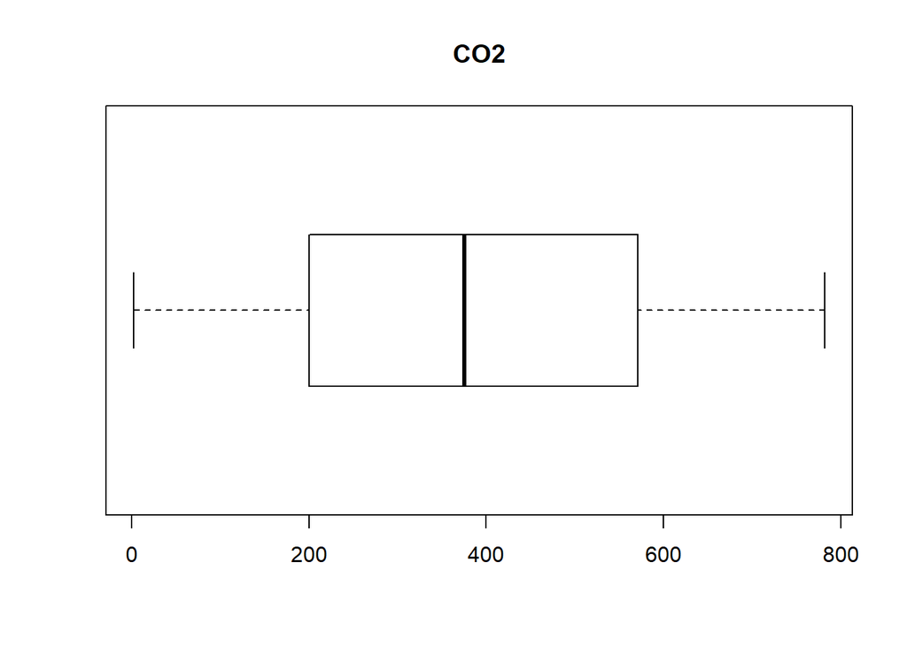

```
## $stats
##      [,1]
## [1,]    2
## [2,]  200
## [3,]  375
## [4,]  571
## [5,]  782
##
## $n
## [1] 921
##
## $conf
##          [,1]
## [1,] 355.6847
## [2,] 394.3153
##
## $out
## numeric(0)
##
## $group
## numeric(0)
##
## $names
## [1] ""
##
## [1] "NOx"
##    Min. 1st Qu.  Median    Mean 3rd Qu.    Max.    NA's
##     2.0   126.0   253.5   263.7   392.2   564.0      88
```

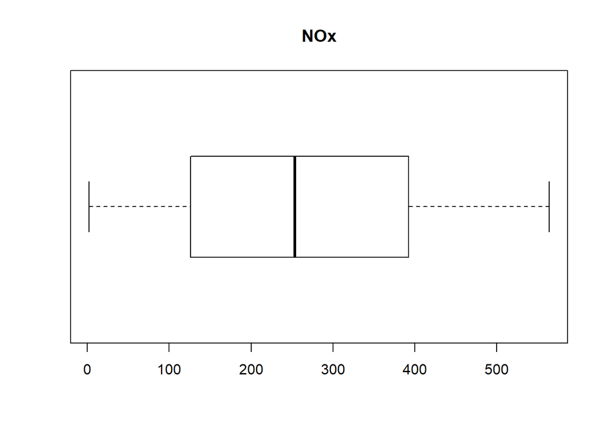

```
## $stats
##       [,1]
## [1,]   2.0
## [2,] 126.0
## [3,] 253.5
## [4,] 392.5
## [5,] 564.0
##
## $n
## [1] 912
##
## $conf
##         [,1]
## [1,] 239.557
## [2,] 267.443
##
## $out
## numeric(0)
##
## $group
## numeric(0)
##
## $names
## [1] ""
##
## [1] "CH4"
##    Min. 1st Qu.  Median    Mean 3rd Qu.    Max.    NA's
##    2.00   80.25  172.50  175.70  263.00  376.00     462
```

[11 more figures not shown]

```
## $stats
##         [,1]
## [1,]     6.0
## [2,]  3008.0
## [3,]  5947.5
## [4,]  8561.0
## [5,] 11172.0
## attr(,"class")
##
## "integer"
##
## $n
## [1] 1000
##
## $conf
##         [,1]
## [1,] 5670.05
## [2,] 6224.95
##
## $out
## numeric(0)
##
## $group
## numeric(0)
##
## $names
## [1] ""
```

```r
# Converting to numeric
for (i in c(23:27,29:31)){
  data[,i]<- as.numeric(data[,i])
}

#summary
name<-colnames(data)
numeric_summary <- function(x){
  for (i in 1:ncol(x)){
    if (is.numeric(x[,i])==TRUE){
      print(name[i])
      print(summary(x[,i]))
      print(boxplot(x[,i],main = name[i],horizontal = TRUE))
    }
  }
}
numeric_summary(data)
```

### Question 6

Write a function to create histograms of numeric columns, such as THC, CO, CO2, and so on in the data set. Use ggplot2 to generate figures.

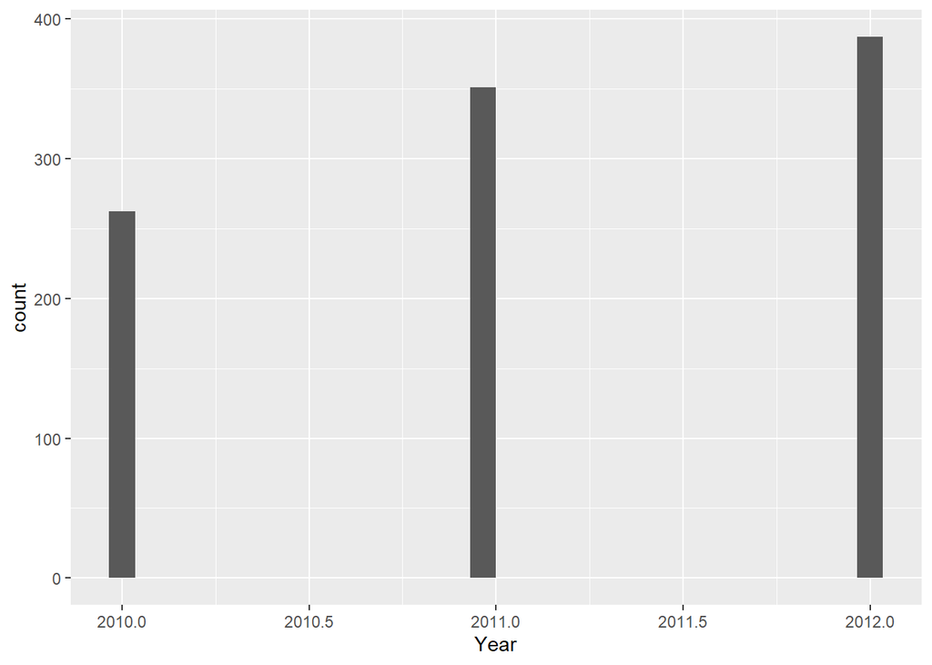

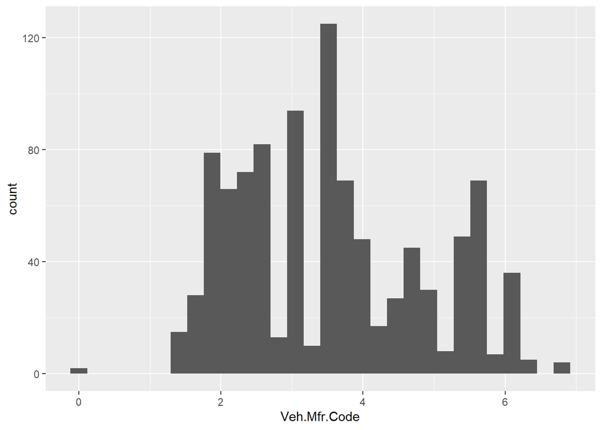

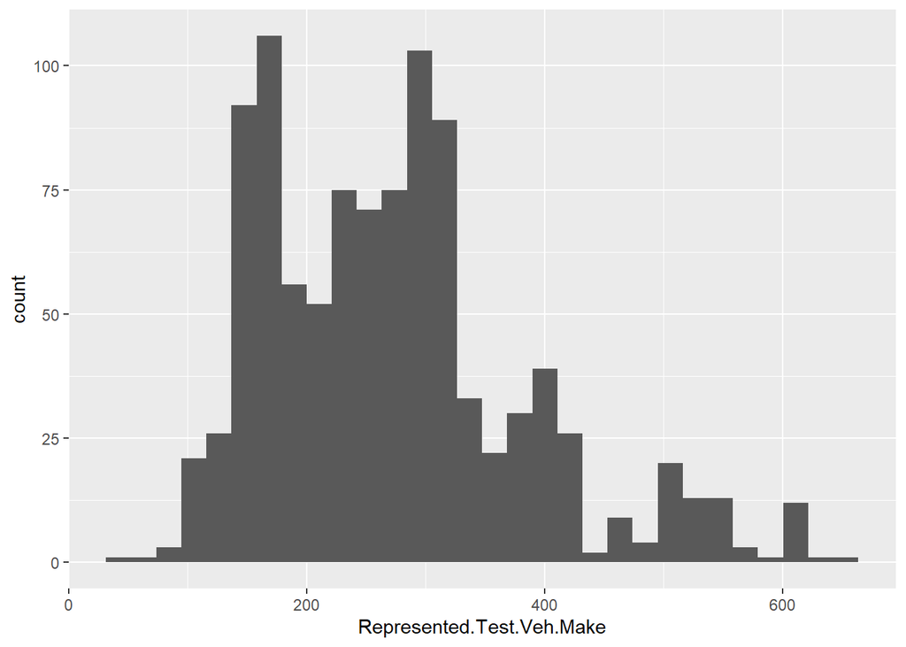

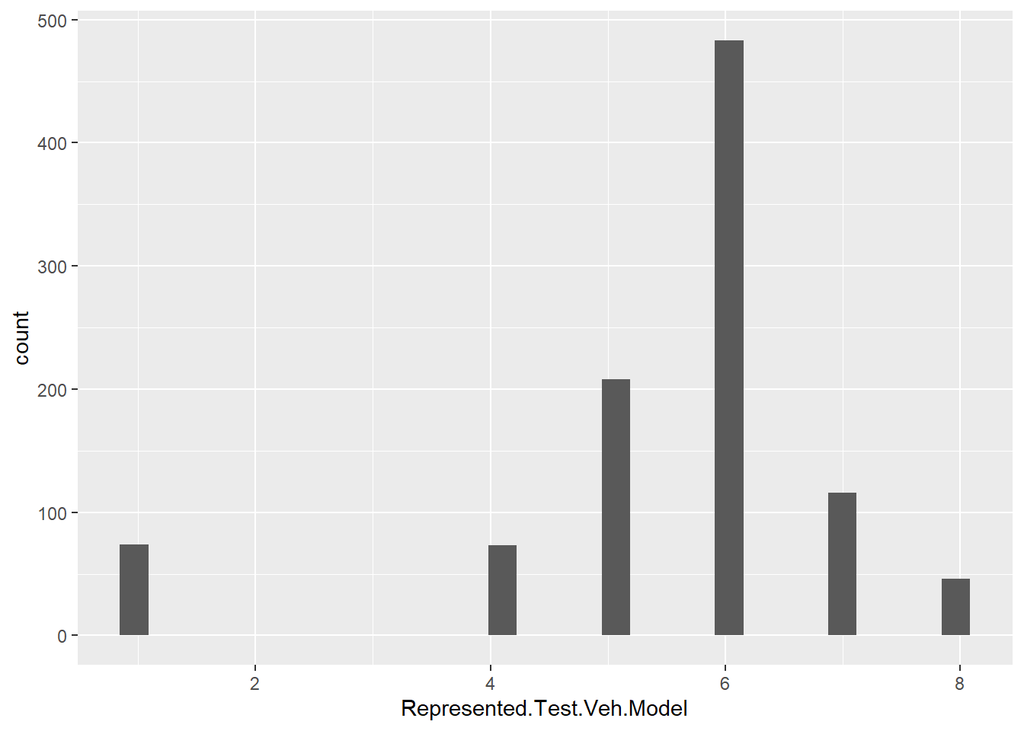

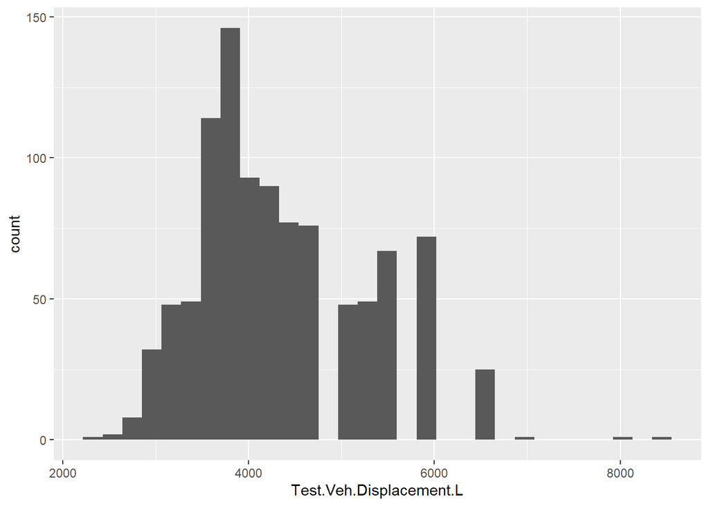

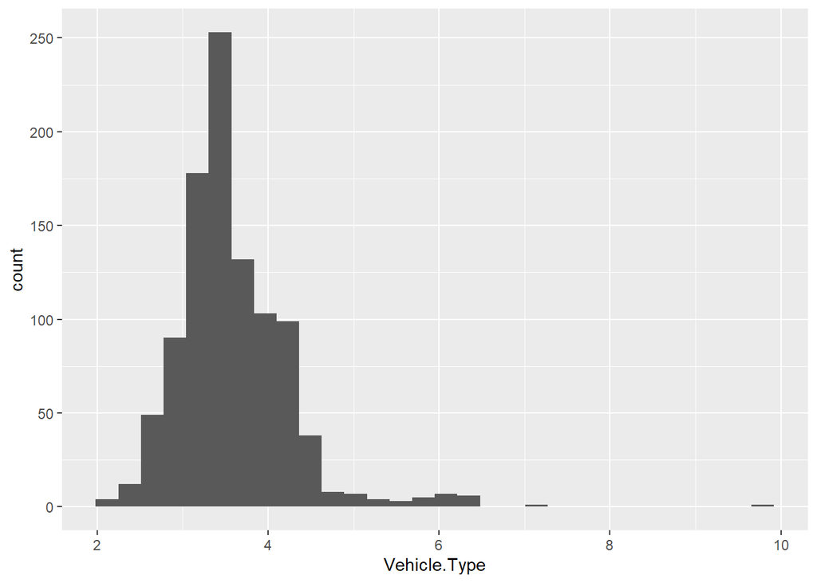

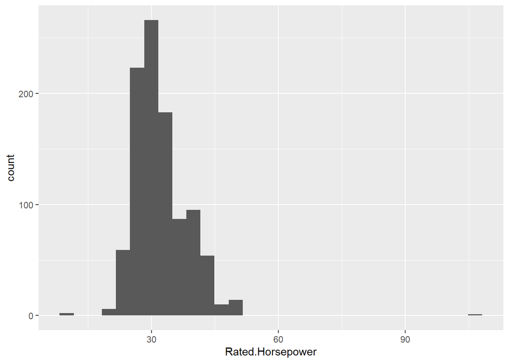

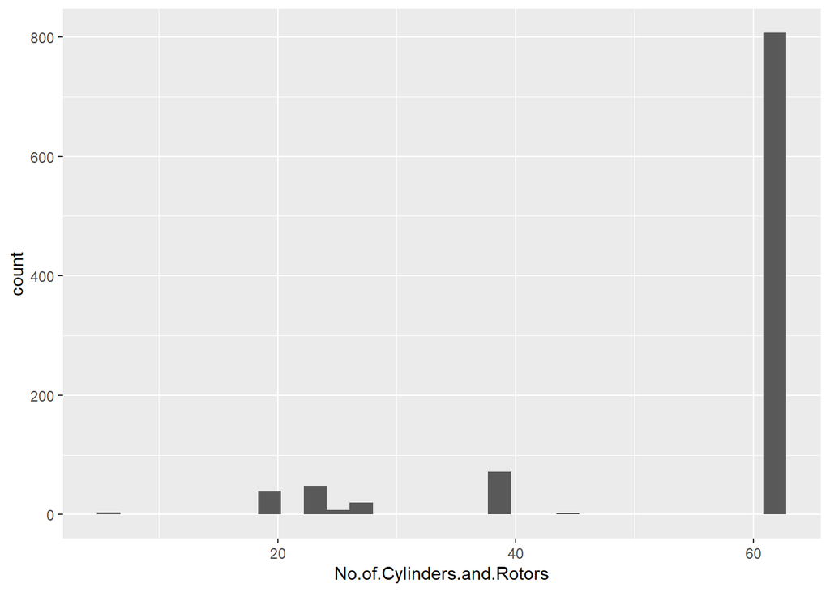

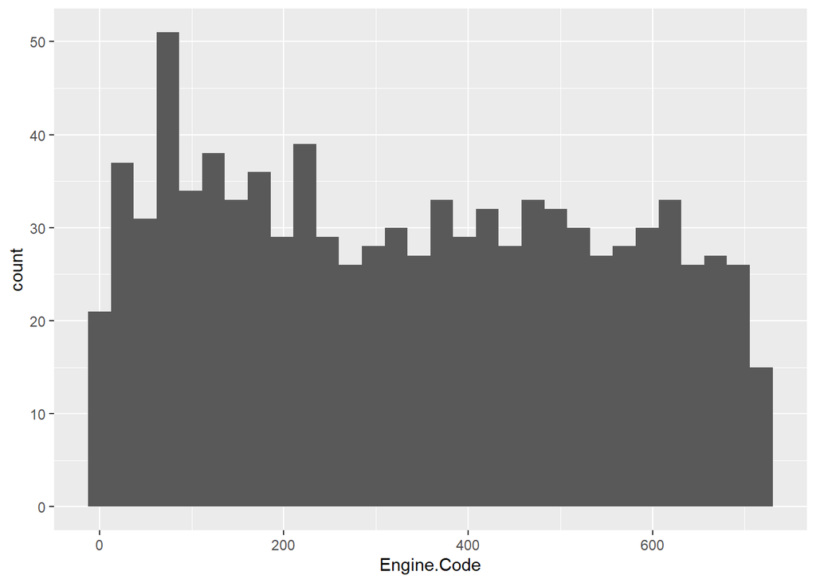

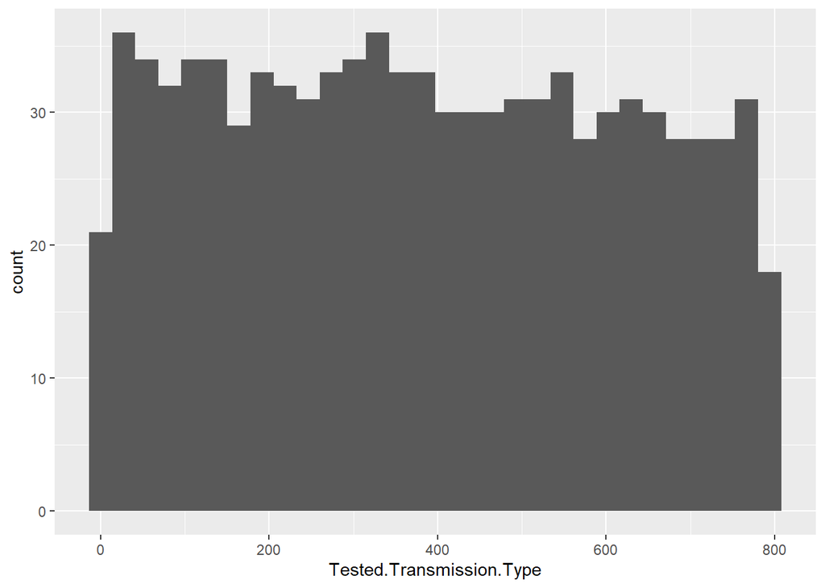

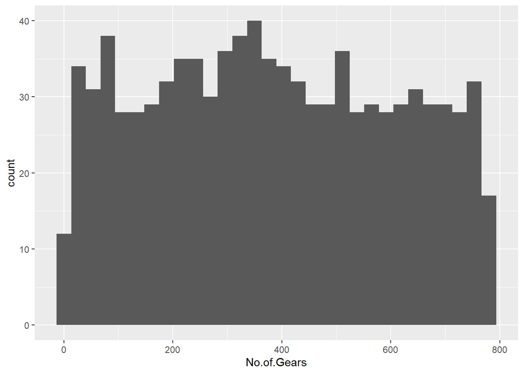

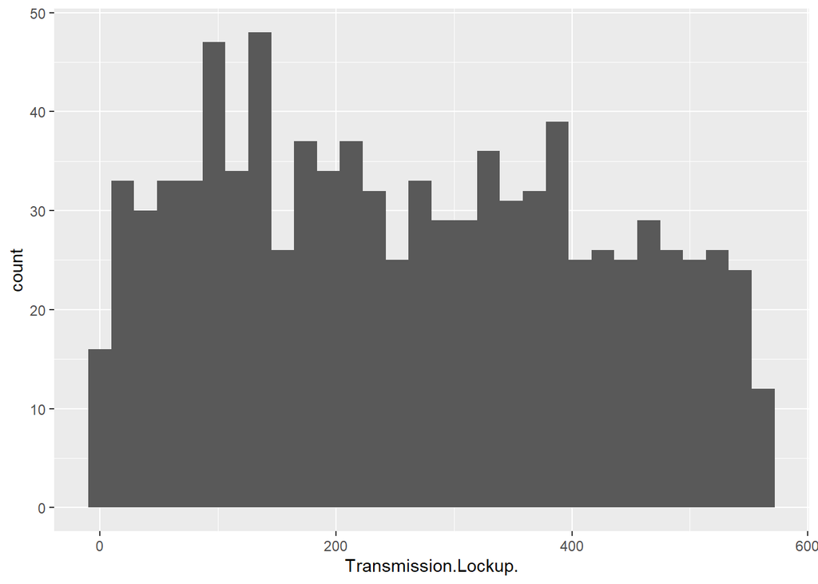

[11 more figures not shown]

```r
library(ggplot2)
library(dplyr)
generate_histogram<- function(x){
  data1 <- x %>% select_if(is.numeric)
  for (i in 1:ncol(data1)){
    print(ggplot(data.frame(data1[,i]),aes(data1[,i]))+geom_histogram(stat="bin")+xlab(name[i]))
  }
}
generate_histogram(data)
```

Subset of real data was given for question 7-10.

### Question 7

The data set contains date columns. All of these date columns are untidy. Please create a better formatted data set. The date should be dd/mm/yyyy in the final format. Use columns 2, 3, and 5 only.

```r
library(anytime)
data7to10 <- read.csv("C:/Users/Lenovo PC/Downloads/cat1.csv",stringsAsFactors=FALSE)
data7to10$First.FD.Date <- format(anytime::anydate(data7to10$First.FD.Date),"%d/%m/%Y")
data7to10$Last.FD.Date <- format(anytime::anydate(data7to10$Last.FD.Date),"%d/%m/%Y")
data7to10$FD.termination.date <- format(anytime::anydate(data7to10$FD.termination.date),"%d/%m/%Y")
head(data7to10,10)
```

```
##    FD.Amount First.FD.Date Last.FD.Date Committed.Period FD.termination.date
## 1       3000    01/05/2015   01/03/2020               60          31/05/2020
## 2       2000    25/06/2015   25/05/2020               60          30/06/2018
## 3       1000    01/07/2015   01/06/2020               60          30/06/2019
## 4       1000    25/06/2015   25/05/2020               60          31/10/2018
## 5       2000    15/07/2015   15/05/2021               71          30/11/2015
## 6       1000    15/04/2015   15/06/2020               63          31/03/2020
## 7       1000    15/06/2015   15/04/2030              181          31/01/2021
## 8       1000    25/06/2015   25/05/2020               60          30/06/2015
## 9       1000    20/02/2015   10/02/2055              487          31/12/2020
## 10      1000    25/04/2015   25/03/2020               60          30/06/2015
##    Actual.Tenure Current_Status Date.of.Birth Gender          Salary
## 1             60        Expired     11-Jun-78      M     5 - 10 lakh
## 2             36     Terminated     12-Mar-70      M     5 - 10 lakh
## 3             47     Terminated     01-May-65      0 less than 1 lac
## 4             40     Terminated     18-Apr-67      F less than 1 lac
## 5              4     Terminated                    M     5 - 10 lakh
## 6             59     Terminated     01-May-67      M less than 1 lac
## 7             67        Live FD     15-Aug-84      F less than 1 lac
## 8              0     Terminated     01-Jan-88      M less than 1 lac
## 9             70        Live FD     07-Aug-87      M less than 1 lac
## 10             2     Terminated     20-Jul-80      M less than 1 lac
```

### Question 8

The date of birth column contains months in string format. Please create a tidy data column with months in numeric format. Now your data should be similar to the previous question.

```r
data7to10$Date.of.Birth <- format(as.Date(data7to10$Date.of.Birth,"%d-%b-%y"),"%d/%m/%Y")
# sum=0
# for (i in data7to10$Date.of.Birth){
#   if (i==" "){
#     sum=sum+1
#   }
# }
# print(sum)
sum(is.na(data7to10$Date.of.Birth)) # 39 rows are missing in original data too
```

```
## [1] 39
```

```r
head(data7to10,10)
```

```
##    FD.Amount First.FD.Date Last.FD.Date Committed.Period FD.termination.date
## 1       3000    01/05/2015   01/03/2020               60          31/05/2020
## 2       2000    25/06/2015   25/05/2020               60          30/06/2018
## 3       1000    01/07/2015   01/06/2020               60          30/06/2019
## 4       1000    25/06/2015   25/05/2020               60          31/10/2018
## 5       2000    15/07/2015   15/05/2021               71          30/11/2015
## 6       1000    15/04/2015   15/06/2020               63          31/03/2020
## 7       1000    15/06/2015   15/04/2030              181          31/01/2021
## 8       1000    25/06/2015   25/05/2020               60          30/06/2015
## 9       1000    20/02/2015   10/02/2055              487          31/12/2020
## 10      1000    25/04/2015   25/03/2020               60          30/06/2015
##    Actual.Tenure Current_Status Date.of.Birth Gender          Salary
## 1             60        Expired    11/06/1978      M     5 - 10 lakh
## 2             36     Terminated    12/03/1970      M     5 - 10 lakh
## 3             47     Terminated    01/05/2065      0 less than 1 lac
## 4             40     Terminated    18/04/2067      F less than 1 lac
## 5              4     Terminated          <NA>      M     5 - 10 lakh
## 6             59     Terminated    01/05/2067      M less than 1 lac
## 7             67        Live FD    15/08/1984      F less than 1 lac
## 8              0     Terminated    01/01/1988      M less than 1 lac
## 9             70        Live FD    07/08/1987      M less than 1 lac
## 10             2     Terminated    20/07/1980      M less than 1 lac
```

### Question 9

Convert all dates into date format; they are currently in character variable format.

```r
#There are 4 dates i.e. in column 2,3,5,8 (already done)
data7to10$First.FD.Date <- as.Date(data7to10$First.FD.Date ,"%d/%m/%Y")
data7to10$Last.FD.Date <- as.Date(data7to10$Last.FD.Date,"%d/%m/%Y")
data7to10$FD.termination.date <- as.Date(data7to10$FD.termination.date,"%d/%m/%Y")
data7to10$Date.of.Birth <- as.Date(data7to10$Date.of.Birth,"%d/%m/%Y")

for (i in c(2,3,5,8)){
  print(class(data7to10[,i]))
}
```

```
## [1] "Date"
## [1] "Date"
## [1] "Date"
## [1] "Date"
```

### Question 10

Create a new column age based on the date of birth column and the first FD column. Date format is necessary to do basic arithmetic.

```r
library(lubridate)
data7to10$Date.of.Birth <- as.Date(data7to10$Date.of.Birth,"%d/%m/%Y") #Converting to Date class
#DoB can't be greater than 2021 as of now
#as.Date adds 20 before any 2 digit year 00-68 and 19 before 69-99
#Loop for correcting that in DoB
for (i in 1:831){
  if (is.na(year(data7to10$Date.of.Birth[i]))==FALSE  && year(data7to10$Date.of.Birth[i]) > 2021){
    year(data7to10$Date.of.Birth[i]) = year(data7to10$Date.of.Birth[i])-100
  }
}

data7to10$Age_years <- as.double(difftime(data7to10$First.FD.Date,data7to10$Date.of.Birth,units="weeks")/52)
head(data7to10,20)
```

```
##    FD.Amount First.FD.Date Last.FD.Date Committed.Period FD.termination.date
## 1       3000    2015-05-01   2020-03-01               60          2020-05-31
## 2       2000    2015-06-25   2020-05-25               60          2018-06-30
## 3       1000    2015-07-01   2020-06-01               60          2019-06-30
## 4       1000    2015-06-25   2020-05-25               60          2018-10-31
## 5       2000    2015-07-15   2021-05-15               71          2015-11-30
## 6       1000    2015-04-15   2020-06-15               63          2020-03-31
## 7       1000    2015-06-15   2030-04-15              181          2021-01-31
## 8       1000    2015-06-25   2020-05-25               60          2015-06-30
## 9       1000    2015-02-20   2055-02-10              487          2020-12-31
## 10      1000    2015-04-25   2020-03-25               60          2015-06-30
## 11      2000    2015-08-10   2020-07-10               60          2020-08-31
## 12      1000    2015-04-10   2020-04-10               61          2015-08-31
## 13      1000    2015-05-25   2020-04-25               60          2016-06-30
## 14      1000    2015-07-25   2020-06-25               60          2020-07-31
```

[output cut: 27 more lines]